# data

Autogenerated data summary from dataMaid

2023-10-08 10:44:16.79888

# Data report overview

The dataset examined has the following dimensions:

| Feature | Result |
| --- | --- |
| Number of observations | 4559 |
| Number of variables | 106 |

### Checks performed

The following variable checks were performed, depending on the data type of each variable:

|  | character | factor | labelled | haven labelled | numeric | integer | logical | Date |
| --- | --- | --- | --- | --- | --- | --- | --- | --- |
| Identify miscoded missing values | × | × | × | × | × | × |  | × |
| Identify prefixed and suffixed whitespace | × | × | × | × |  |  |  |  |
| Identify levels with < 6 obs. | × | × | × | × |  |  |  |  |
| Identify case issues | × | × | × | × |  |  |  |  |
| Identify misclassified numeric or integer variables | × | × | × | × |  |  |  |  |
| Identify outliers |  |  |  |  | × | × |  | × |

Please note that all numerical values in the following have been rounded to 2 decimals.

# Summary table

|  | Variable class | # unique values | Missing observations | Any problems? |
| --- | --- | --- | --- | --- |
| icustay_id…1 | numeric | 4559 | 0.00 % |  |
| hadm_id…2 | numeric | 4559 | 0.00 % |  |
| intime | character | 4559 | 0.00 % | × |
| outtime | character | 4559 | 0.00 % | × |
| dbsource | character | 1 | 0.00 % | × |
| suspected_infection_time_poe | character | 4558 | 0.00 % | × |
| suspected_infection_time_poe_days | numeric | 4370 | 0.00 % | × |
| specimen_poe | character | 35 | 0.00 % | × |
| positiveculture_poe | numeric | 2 | 0.00 % |  |
| antibiotic_time_poe | character | 4274 | 0.00 % | × |
| blood_culture_time | character | 4558 | 0.00 % | × |
| blood_culture_positive | numeric | 2 | 0.00 % |  |
| age | numeric | 3831 | 0.00 % |  |
| gender | character | 2 | 0.00 % |  |
| is_male | numeric | 2 | 0.00 % |  |
| ethnicity | character | 41 | 0.00 % | × |
| race_white | numeric | 2 | 0.00 % |  |
| race_black | numeric | 2 | 0.00 % |  |
| race_hispanic | numeric | 2 | 0.00 % |  |
| race_other | numeric | 2 | 0.00 % |  |
| metastatic_cancer | numeric | 2 | 0.00 % |  |
| diabetes | numeric | 2 | 0.00 % |  |
| first_service | character | 13 | 0.00 % |  |
| hospital_expire_flag | numeric | 2 | 0.00 % |  |
| thirtyday_expire_flag | numeric | 2 | 0.00 % |  |
| icu_los | numeric | 4401 | 0.00 % | × |
| hosp_los | numeric | 4191 | 0.00 % | × |
| sepsis_angus | numeric | 2 | 0.00 % |  |
| sepsis_martin | numeric | 2 | 0.00 % |  |
| sepsis_explicit | numeric | 2 | 0.00 % |  |

[output cut: 76 more lines]

# Variable list

## icustay_id…1

| Feature | Result |
| --- | --- |
| Variable type | numeric |
| Number of missing obs. | 0 (0 %) |
| Number of unique values | 4559 |
| Median | 251008 |
| 1st and 3rd quartiles | 225575.5; 275526 |
| Min. and max. | 200075; 299998 |

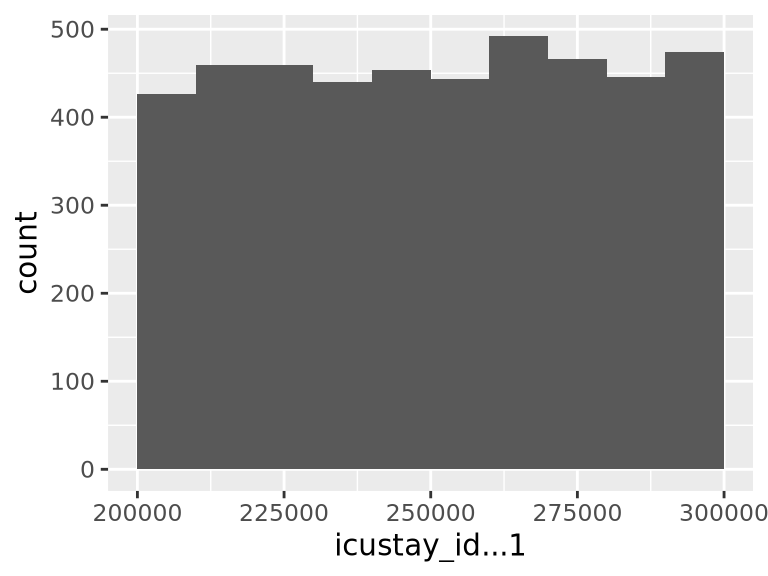

## hadm_id…2

| Feature | Result |
| --- | --- |
| Variable type | numeric |
| Number of missing obs. | 0 (0 %) |
| Number of unique values | 4559 |
| Median | 149643 |
| 1st and 3rd quartiles | 125389; 175033 |
| Min. and max. | 100003; 199962 |

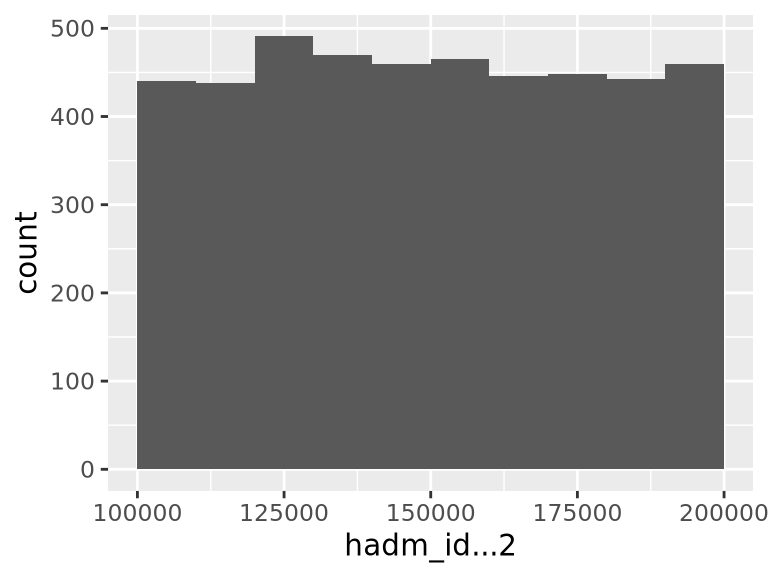

## intime

- The variable is a key (distinct values for each observation).

## outtime

- The variable is a key (distinct values for each observation).

## dbsource

- The variable only takes one (non-missing) value: "metavision". The variable contains 0 % missing observations.

## suspected_infection_time_poe

| Feature | Result |
| --- | --- |
| Variable type | character |
| Number of missing obs. | 0 (0 %) |
| Number of unique values | 4558 |
| Mode | “18/8/2159 00:00:00” |

[figure not shown]

- Note that the following levels have at most five observations: "1/1/2118 1:02", "1/1/2118 14:36", "1/1/2125 14:05", "1/1/2132 21:00", "1/1/2135 15:55", …, "9/9/2184 10:25", "9/9/2185 18:24", "9/9/2186 18:18", "9/9/2188 1:05", "9/9/2198 18:30" (4548 values omitted).

## suspected_infection_time_poe_days

| Feature | Result |
| --- | --- |
| Variable type | numeric |
| Number of missing obs. | 0 (0 %) |
| Number of unique values | 4370 |
| Median | 0.03 |
| 1st and 3rd quartiles | -0.08; 0.16 |
| Min. and max. | -0.99; 1 |

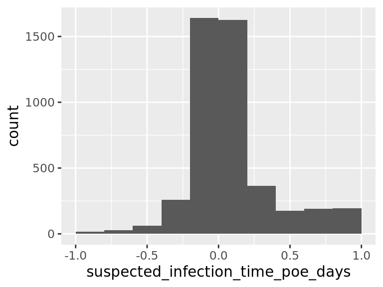

- Note that the following possible outlier values were detected: "-0.99", "-0.98", "-0.93", "-0.93", "-0.92", …, "0.99", "0.99", "0.99", "0.99", "1" (519 values omitted).

## specimen_poe

| Feature | Result |
| --- | --- |
| Variable type | character |
| Number of missing obs. | 0 (0 %) |
| Number of unique values | 35 |
| Mode | “BLOOD CULTURE” |

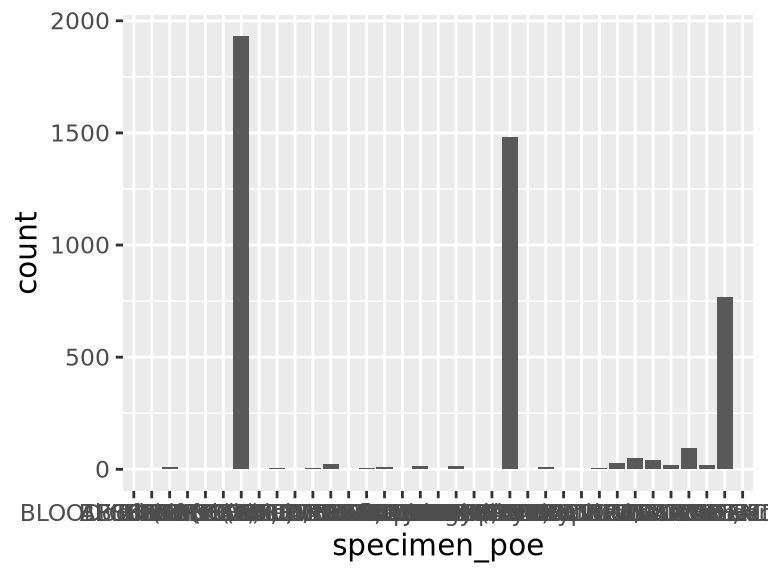

- Note that the following levels have at most five observations: "ABSCESS", "BILE", "Blood (EBV)", "Blood (Malaria)", "Blood (Toxo)", …, "NEOPLASTIC BLOOD", "PLEURAL FLUID", "RAPID RESPIRATORY VIRAL ANTIGEN TEST", "Rapid Respiratory Viral Screen & Culture", "URINE,KIDNEY" (10 values omitted).

## positiveculture_poe

- Note that this variable is treated as a factor variable below, as it only takes a few unique values.

| Feature | Result |
| --- | --- |
| Variable type | numeric |
| Number of missing obs. | 0 (0 %) |
| Number of unique values | 2 |
| Mode | “0” |
| Reference category | 0 |

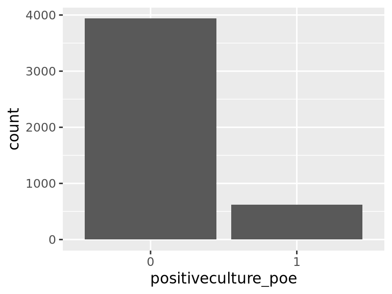

## antibiotic_time_poe

| Feature | Result |
| --- | --- |
| Variable type | character |
| Number of missing obs. | 0 (0 %) |
| Number of unique values | 4274 |
| Mode | “1/4/2191 0:00” |

[figure not shown]

- Note that the following levels have at most five observations: "1/1/2111 0:00", "1/1/2116 0:00", "1/1/2130 0:00", "1/1/2134 0:00", "1/1/2135 0:00", …, "9/9/2181 0:00", "9/9/2185 0:00", "9/9/2187 0:00", "9/9/2189 0:00", "9/9/2198 0:00" (4264 values omitted).

## blood_culture_time

| Feature | Result |
| --- | --- |
| Variable type | character |
| Number of missing obs. | 0 (0 %) |
| Number of unique values | 4558 |
| Mode | “18/8/2159 00:00:00” |

[figure not shown]

- Note that the following levels have at most five observations: "1/1/2113 20:45", "1/1/2118 1:02", "1/1/2118 14:36", "1/1/2125 14:05", "1/1/2132 21:00", …, "9/9/2184 10:25", "9/9/2185 18:24", "9/9/2186 18:18", "9/9/2188 1:05", "9/9/2198 18:30" (4548 values omitted).

## blood_culture_positive

- Note that this variable is treated as a factor variable below, as it only takes a few unique values.

| Feature | Result |
| --- | --- |
| Variable type | numeric |
| Number of missing obs. | 0 (0 %) |
| Number of unique values | 2 |
| Mode | “0” |
| Reference category | 0 |

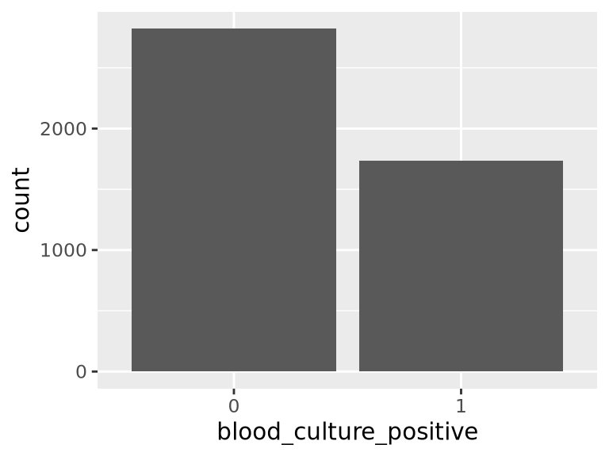

## age

| Feature | Result |
| --- | --- |
| Variable type | numeric |
| Number of missing obs. | 0 (0 %) |
| Number of unique values | 3831 |
| Median | 66.59 |
| 1st and 3rd quartiles | 53.76; 79.53 |
| Min. and max. | 16.78; 91.4 |

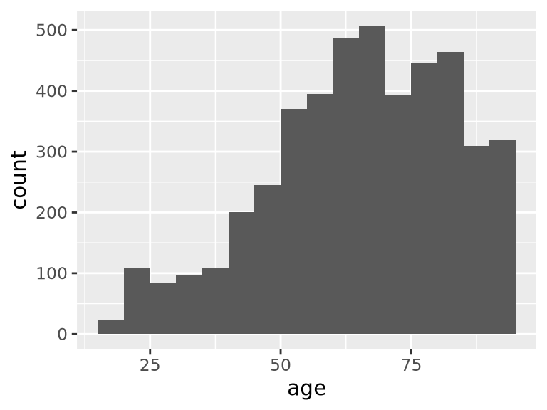

## gender

| Feature | Result |
| --- | --- |
| Variable type | character |
| Number of missing obs. | 0 (0 %) |
| Number of unique values | 2 |
| Mode | “M” |

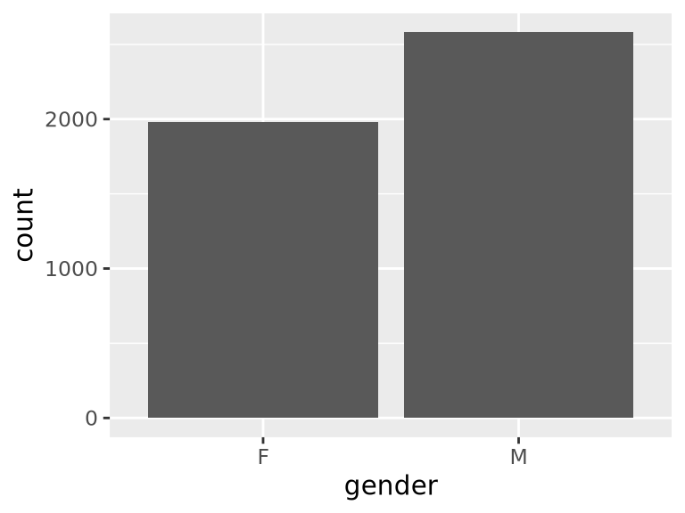

## is_male

- Note that this variable is treated as a factor variable below, as it only takes a few unique values.

| Feature | Result |
| --- | --- |
| Variable type | numeric |
| Number of missing obs. | 0 (0 %) |
| Number of unique values | 2 |
| Mode | “1” |
| Reference category | 0 |

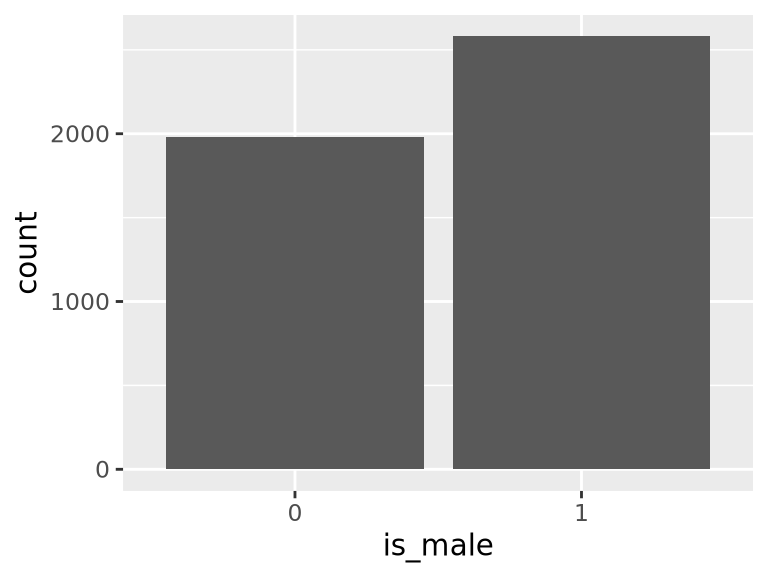

## ethnicity

| Feature | Result |
| --- | --- |
| Variable type | character |
| Number of missing obs. | 0 (0 %) |
| Number of unique values | 41 |
| Mode | “WHITE” |

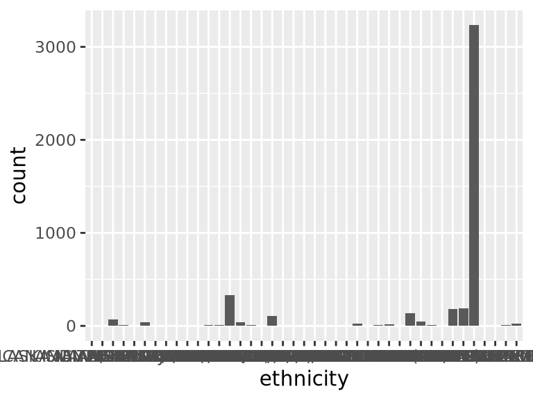

- Note that the following levels have at most five observations: "AMERICAN INDIAN/ALASKA NATIVE", "AMERICAN INDIAN/ALASKA NATIVE FEDERALLY RECOGNIZED TRIBE", "ASIAN - CAMBODIAN", "ASIAN - FILIPINO", "ASIAN - JAPANESE", …, "HISPANIC/LATINO - SALVADORAN", "NATIVE HAWAIIAN OR OTHER PACIFIC ISLANDER", "SOUTH AMERICAN", "WHITE - BRAZILIAN", "WHITE - EASTERN EUROPEAN" (11 values omitted).

## race_white

- Note that this variable is treated as a factor variable below, as it only takes a few unique values.

| Feature | Result |
| --- | --- |
| Variable type | numeric |
| Number of missing obs. | 0 (0 %) |
| Number of unique values | 2 |
| Mode | “1” |
| Reference category | 0 |

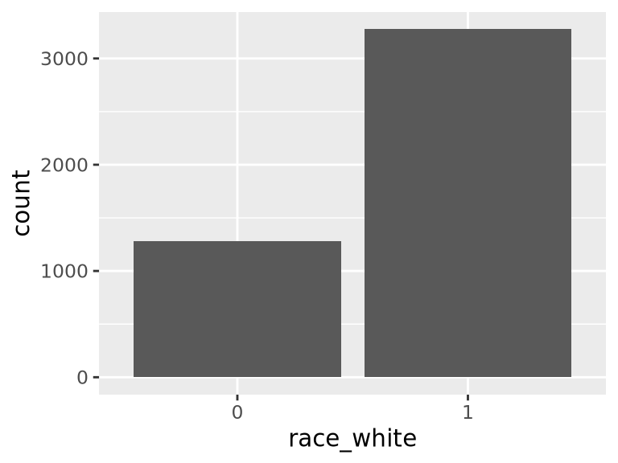

## race_black

- Note that this variable is treated as a factor variable below, as it only takes a few unique values.

| Feature | Result |
| --- | --- |
| Variable type | numeric |
| Number of missing obs. | 0 (0 %) |
| Number of unique values | 2 |
| Mode | “0” |
| Reference category | 0 |

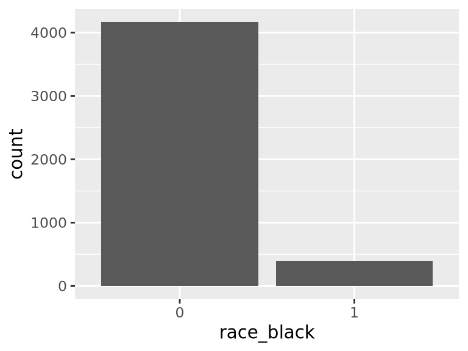

## race_hispanic

- Note that this variable is treated as a factor variable below, as it only takes a few unique values.

| Feature | Result |
| --- | --- |
| Variable type | numeric |
| Number of missing obs. | 0 (0 %) |
| Number of unique values | 2 |
| Mode | “0” |
| Reference category | 0 |

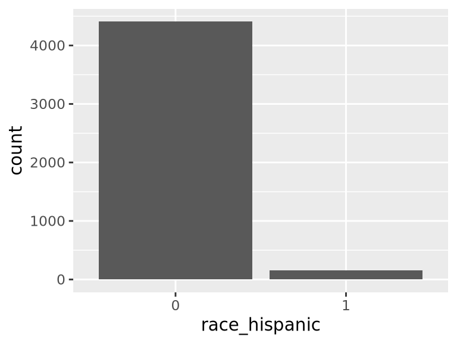

## race_other

- Note that this variable is treated as a factor variable below, as it only takes a few unique values.

| Feature | Result |
| --- | --- |
| Variable type | numeric |
| Number of missing obs. | 0 (0 %) |
| Number of unique values | 2 |
| Mode | “0” |
| Reference category | 0 |

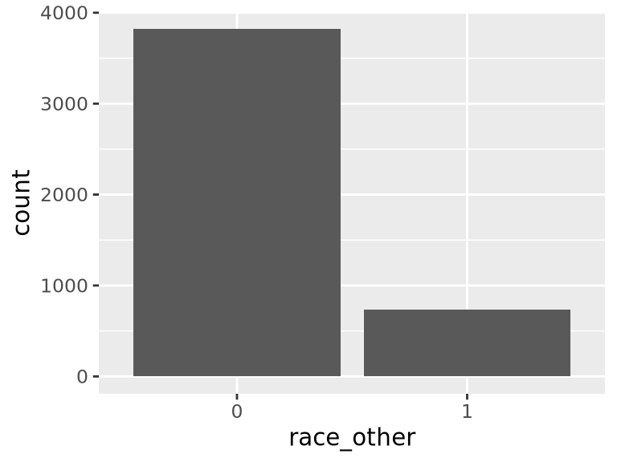

## metastatic_cancer

- Note that this variable is treated as a factor variable below, as it only takes a few unique values.

| Feature | Result |
| --- | --- |
| Variable type | numeric |
| Number of missing obs. | 0 (0 %) |
| Number of unique values | 2 |
| Mode | “0” |
| Reference category | 0 |

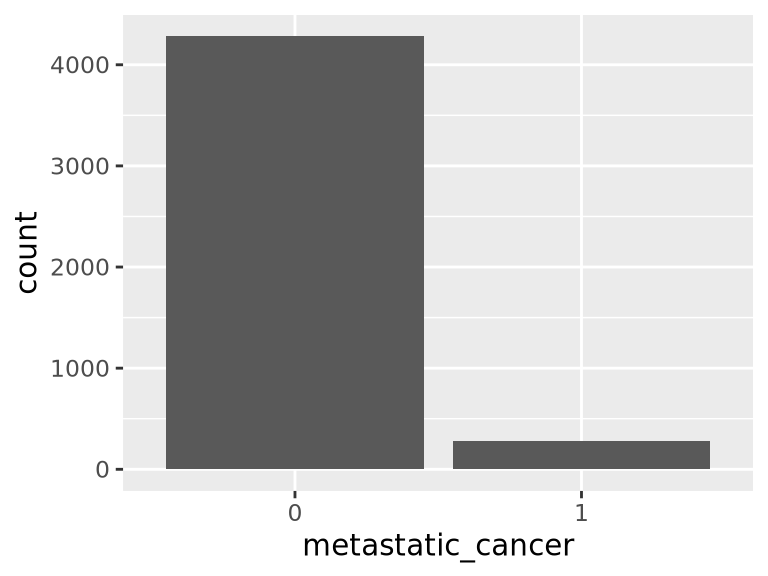

## diabetes

- Note that this variable is treated as a factor variable below, as it only takes a few unique values.

| Feature | Result |
| --- | --- |
| Variable type | numeric |
| Number of missing obs. | 0 (0 %) |
| Number of unique values | 2 |
| Mode | “0” |
| Reference category | 0 |

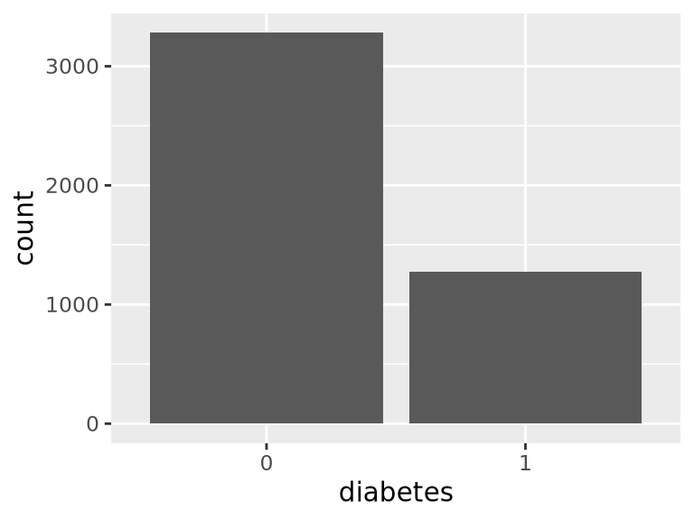

## first_service

| Feature | Result |
| --- | --- |
| Variable type | character |
| Number of missing obs. | 0 (0 %) |
| Number of unique values | 13 |
| Mode | “MED” |

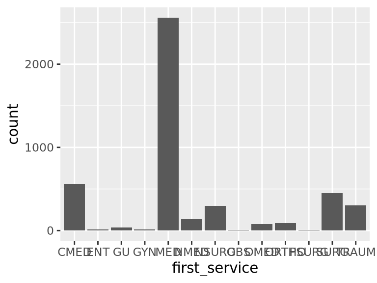

## hospital_expire_flag

- Note that this variable is treated as a factor variable below, as it only takes a few unique values.

| Feature | Result |
| --- | --- |
| Variable type | numeric |
| Number of missing obs. | 0 (0 %) |
| Number of unique values | 2 |
| Mode | “0” |
| Reference category | 0 |

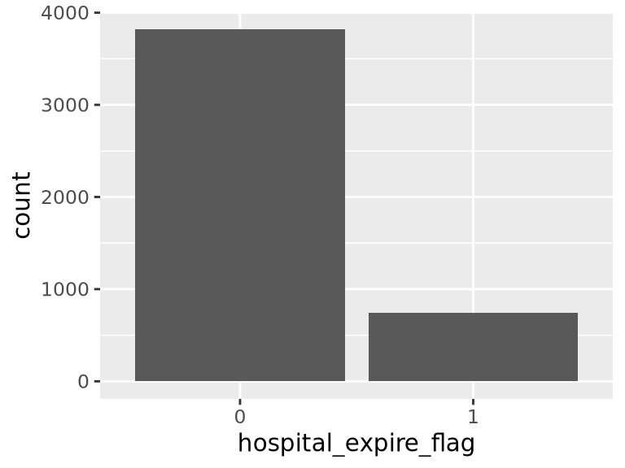

## thirtyday_expire_flag

- Note that this variable is treated as a factor variable below, as it only takes a few unique values.

| Feature | Result |
| --- | --- |
| Variable type | numeric |
| Number of missing obs. | 0 (0 %) |
| Number of unique values | 2 |
| Mode | “0” |
| Reference category | 0 |

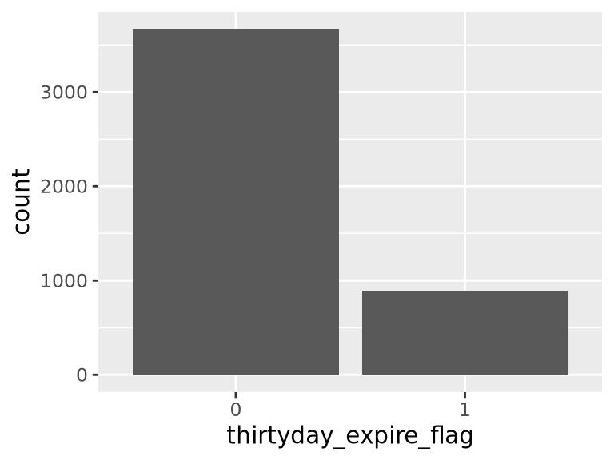

## icu_los

| Feature | Result |
| --- | --- |
| Variable type | numeric |
| Number of missing obs. | 0 (0 %) |
| Number of unique values | 4401 |
| Median | 2.82 |
| 1st and 3rd quartiles | 1.61; 5.87 |
| Min. and max. | 0.17; 101.74 |

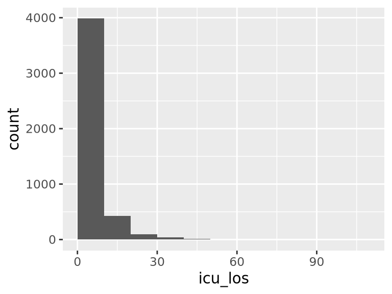

- Note that the following possible outlier values were detected: "0.17", "0.25", "0.25", "0.3", "0.31", …, "59.47", "60.94", "61.93", "79.11", "101.74" (96 values omitted).

## hosp_los

| Feature | Result |
| --- | --- |
| Variable type | numeric |
| Number of missing obs. | 0 (0 %) |
| Number of unique values | 4191 |
| Median | 7.79 |
| 1st and 3rd quartiles | 4.73; 13.03 |
| Min. and max. | -0.43; 206.43 |

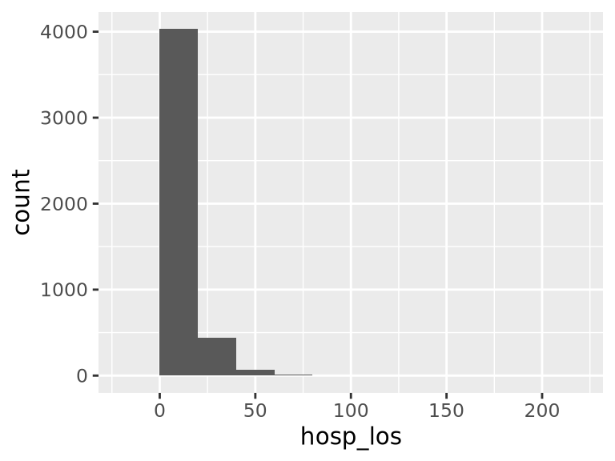

- Note that the following possible outlier values were detected: "-0.43", "-0.06", "0.11", "0.17", "0.18", …, "100.49", "101.62", "123.13", "133.1", "206.43" (207 values omitted).

## sepsis_angus

- Note that this variable is treated as a factor variable below, as it only takes a few unique values.

| Feature | Result |
| --- | --- |
| Variable type | numeric |
| Number of missing obs. | 0 (0 %) |
| Number of unique values | 2 |
| Mode | “1” |
| Reference category | 0 |

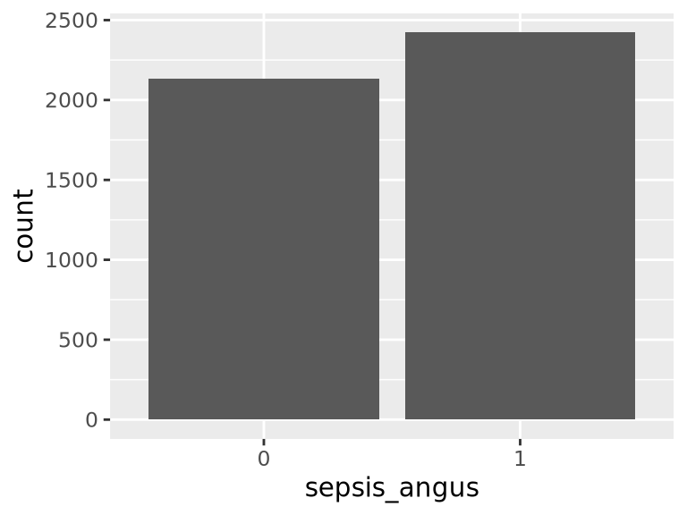

## sepsis_martin

- Note that this variable is treated as a factor variable below, as it only takes a few unique values.

| Feature | Result |
| --- | --- |
| Variable type | numeric |
| Number of missing obs. | 0 (0 %) |
| Number of unique values | 2 |
| Mode | “0” |
| Reference category | 0 |

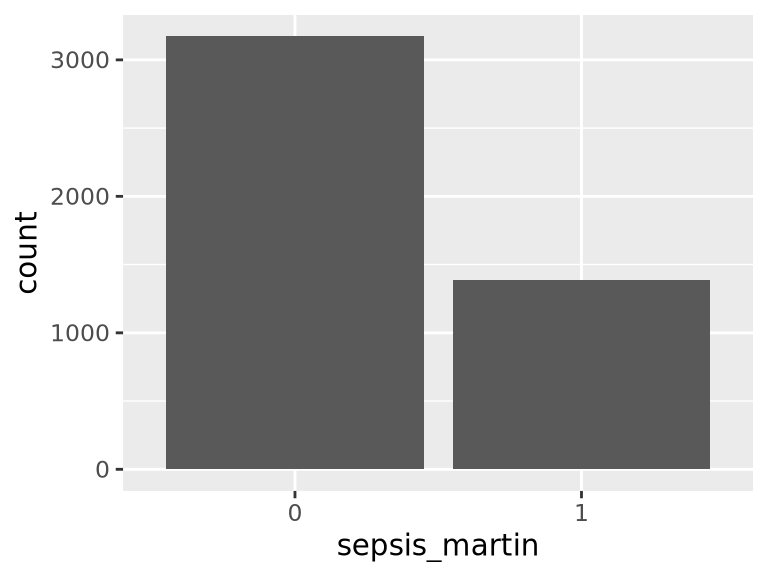

## sepsis_explicit

- Note that this variable is treated as a factor variable below, as it only takes a few unique values.

| Feature | Result |
| --- | --- |
| Variable type | numeric |
| Number of missing obs. | 0 (0 %) |
| Number of unique values | 2 |
| Mode | “0” |
| Reference category | 0 |

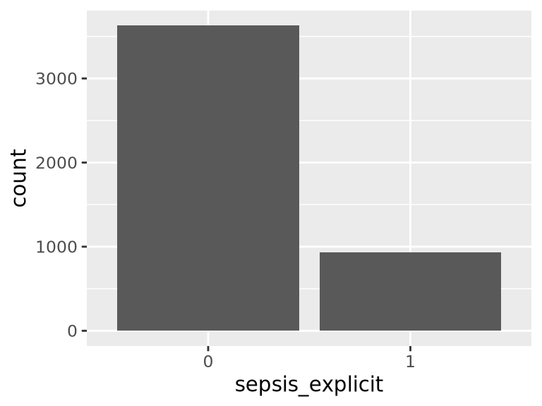

## septic_shock_explicit

- Note that this variable is treated as a factor variable below, as it only takes a few unique values.

| Feature | Result |
| --- | --- |
| Variable type | numeric |
| Number of missing obs. | 0 (0 %) |
| Number of unique values | 2 |
| Mode | “0” |
| Reference category | 0 |

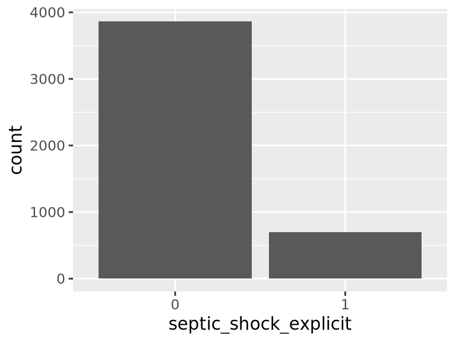

## severe_sepsis_explicit

- Note that this variable is treated as a factor variable below, as it only takes a few unique values.

| Feature | Result |
| --- | --- |
| Variable type | numeric |
| Number of missing obs. | 0 (0 %) |
| Number of unique values | 2 |
| Mode | “0” |
| Reference category | 0 |

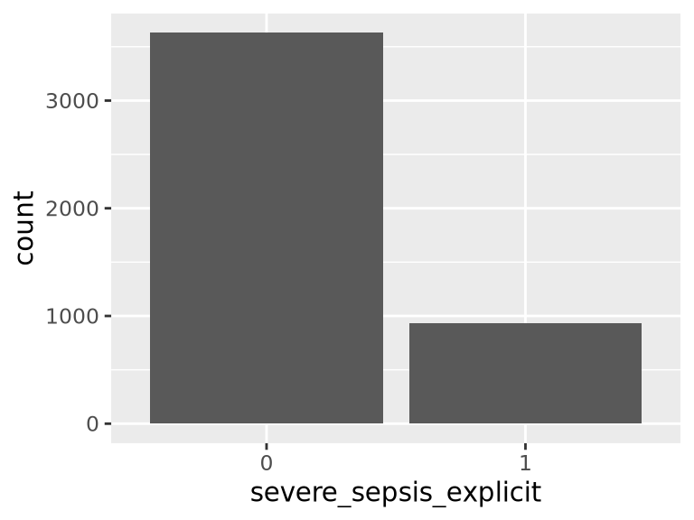

## sepsis_nqf

- Note that this variable is treated as a factor variable below, as it only takes a few unique values.

| Feature | Result |
| --- | --- |
| Variable type | numeric |
| Number of missing obs. | 0 (0 %) |
| Number of unique values | 2 |
| Mode | “0” |
| Reference category | 0 |

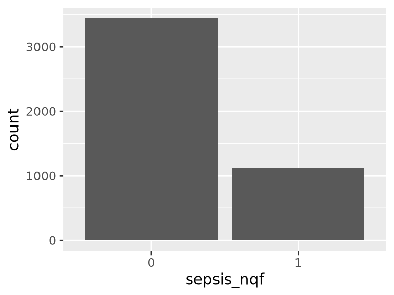

## sepsis_cdc

- Note that this variable is treated as a factor variable below, as it only takes a few unique values.

| Feature | Result |
| --- | --- |
| Variable type | numeric |
| Number of missing obs. | 0 (0 %) |
| Number of unique values | 2 |
| Mode | “1” |
| Reference category | 0 |

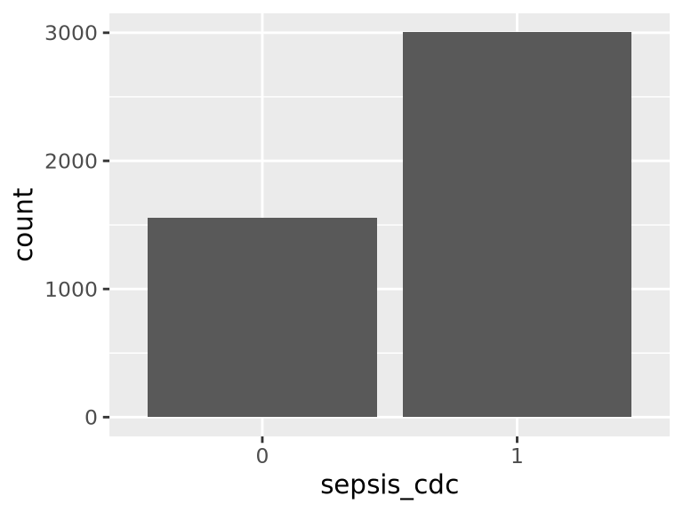

## sepsis_cdc_simple

- Note that this variable is treated as a factor variable below, as it only takes a few unique values.

| Feature | Result |
| --- | --- |
| Variable type | numeric |
| Number of missing obs. | 0 (0 %) |
| Number of unique values | 2 |
| Mode | “1” |
| Reference category | 0 |

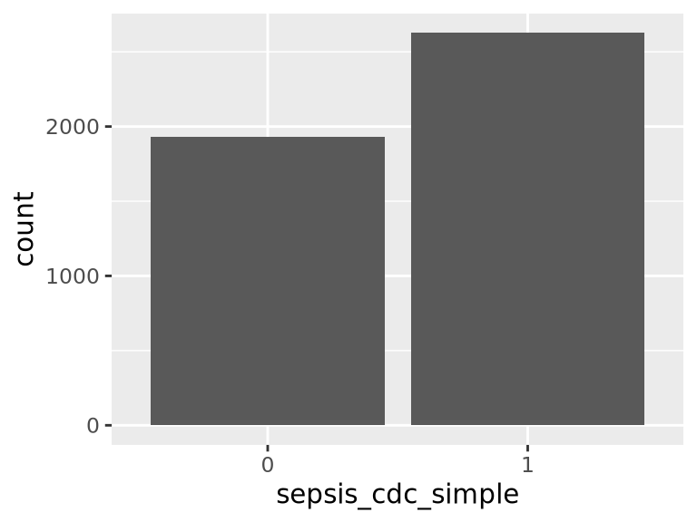

## elixhauser_hospital

| Feature | Result |
| --- | --- |
| Variable type | numeric |
| Number of missing obs. | 0 (0 %) |
| Number of unique values | 49 |
| Median | 4 |
| 1st and 3rd quartiles | 0; 9 |
| Min. and max. | -23; 30 |

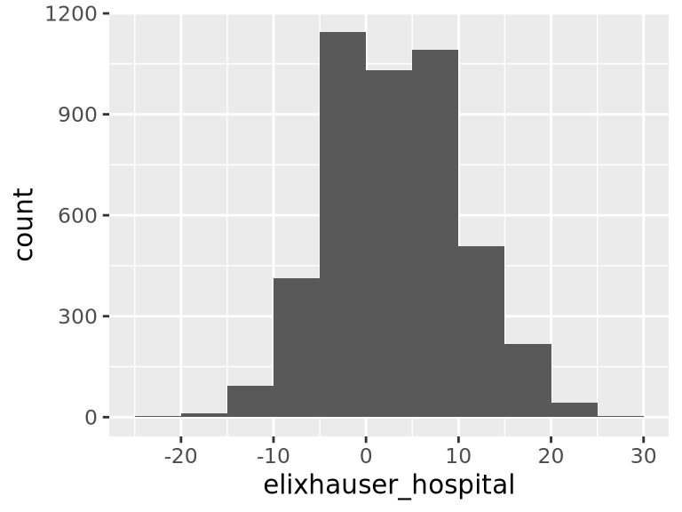

- Note that the following possible outlier values were detected: "-23", "-21", "-20", "-19", "-16", …, "24", "25", "27", "28", "30" (3 values omitted).

## vent

- Note that this variable is treated as a factor variable below, as it only takes a few unique values.

| Feature | Result |
| --- | --- |
| Variable type | numeric |
| Number of missing obs. | 0 (0 %) |
| Number of unique values | 2 |
| Mode | “1” |
| Reference category | 0 |

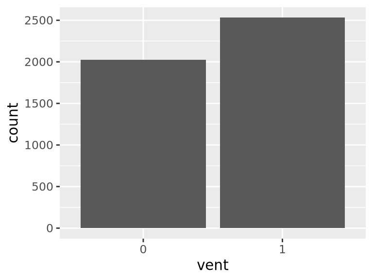

## sofa

| Feature | Result |
| --- | --- |
| Variable type | numeric |
| Number of missing obs. | 0 (0 %) |
| Number of unique values | 20 |
| Median | 5 |
| 1st and 3rd quartiles | 3; 7 |
| Min. and max. | 2; 21 |

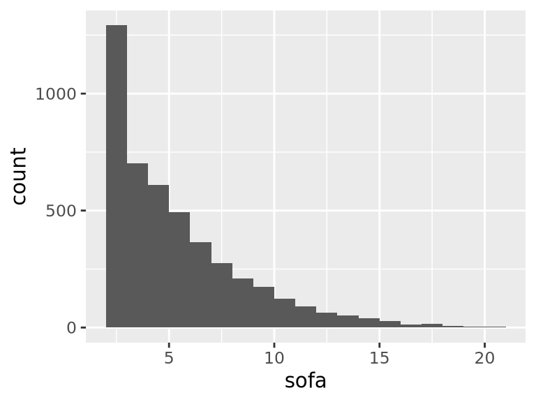

- Note that the following possible outlier values were detected: "18", "19", "20", "21".

## lods

| Feature | Result |
| --- | --- |
| Variable type | numeric |
| Number of missing obs. | 0 (0 %) |
| Number of unique values | 21 |
| Median | 5 |
| 1st and 3rd quartiles | 3; 7 |
| Min. and max. | 0; 20 |

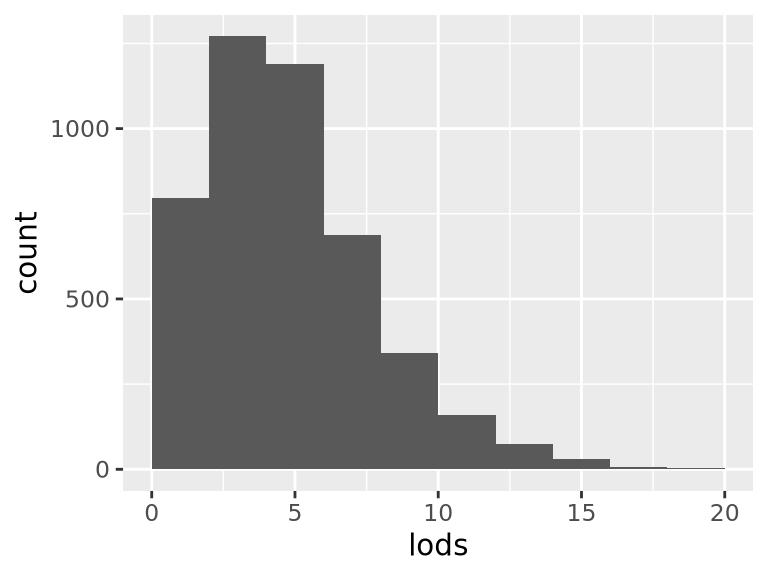

- Note that the following possible outlier values were detected: "14", "15", "16", "17", "18", "19", "20".

## sirs

- Note that this variable is treated as a factor variable below, as it only takes a few unique values.

| Feature | Result |
| --- | --- |
| Variable type | numeric |
| Number of missing obs. | 0 (0 %) |
| Number of unique values | 5 |
| Mode | “3” |
| Reference category | 0 |

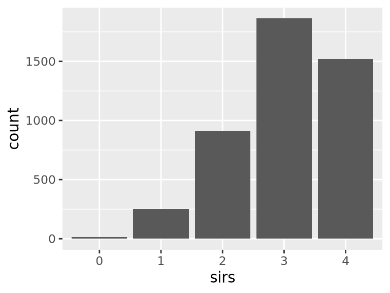

## qsofa

- Note that this variable is treated as a factor variable below, as it only takes a few unique values.

| Feature | Result |
| --- | --- |
| Variable type | numeric |
| Number of missing obs. | 0 (0 %) |
| Number of unique values | 4 |
| Mode | “2” |
| Reference category | 0 |

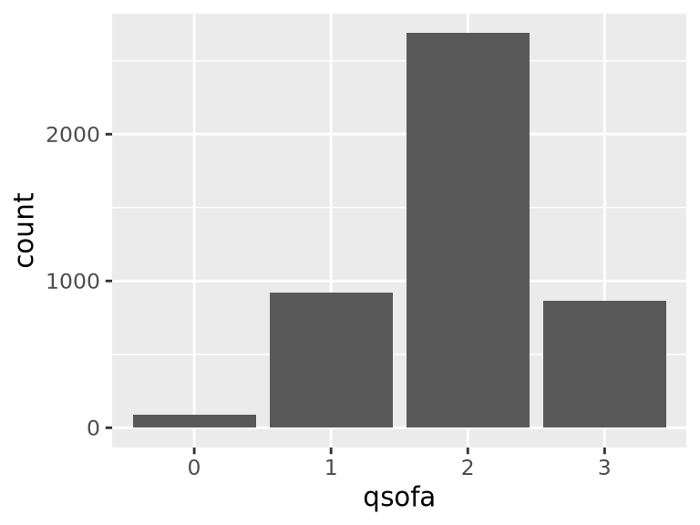

## qsofa_sysbp_score

- Note that this variable is treated as a factor variable below, as it only takes a few unique values.

| Feature | Result |
| --- | --- |
| Variable type | numeric |
| Number of missing obs. | 7 (0.15 %) |
| Number of unique values | 2 |
| Mode | “1” |
| Reference category | 0 |

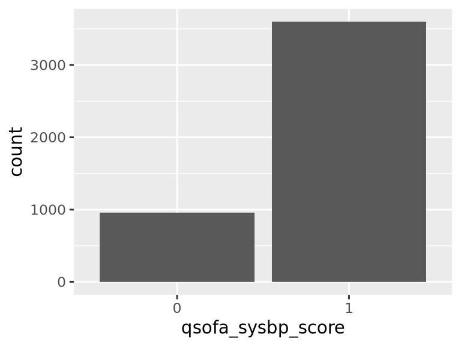

## qsofa_gcs_score

- Note that this variable is treated as a factor variable below, as it only takes a few unique values.

| Feature | Result |
| --- | --- |
| Variable type | numeric |
| Number of missing obs. | 3 (0.07 %) |
| Number of unique values | 2 |
| Mode | “0” |
| Reference category | 0 |

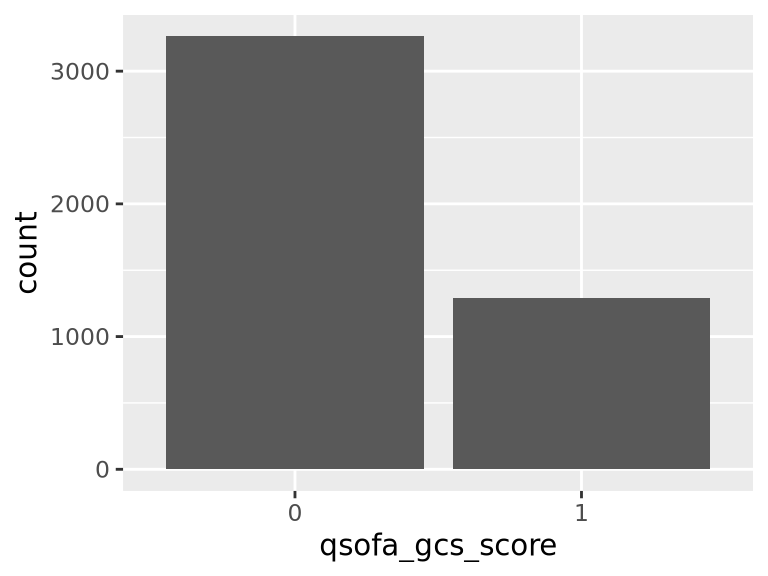

## qsofa_resprate_score

- Note that this variable is treated as a factor variable below, as it only takes a few unique values.

| Feature | Result |
| --- | --- |
| Variable type | numeric |
| Number of missing obs. | 1 (0.02 %) |
| Number of unique values | 2 |
| Mode | “1” |
| Reference category | 0 |

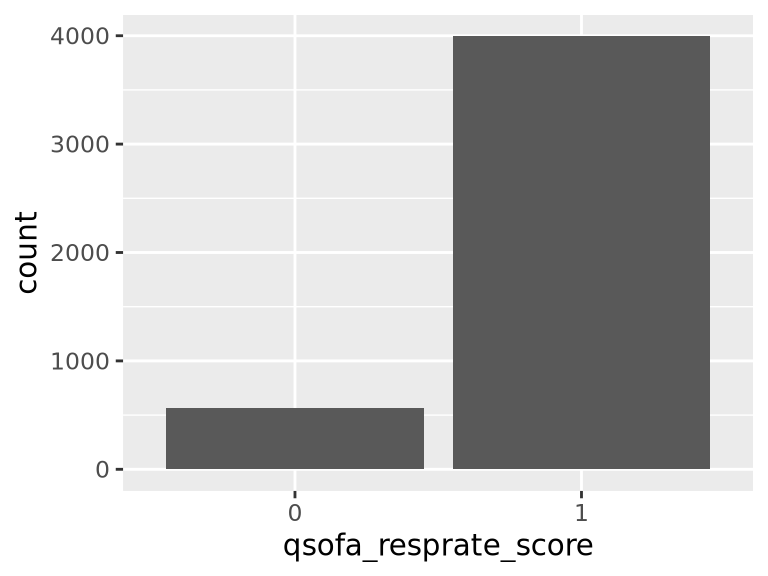

## aniongap_min

| Feature | Result |
| --- | --- |
| Variable type | numeric |
| Number of missing obs. | 14 (0.31 %) |
| Number of unique values | 34 |
| Median | 12 |
| 1st and 3rd quartiles | 10; 15 |
| Min. and max. | 3; 42 |

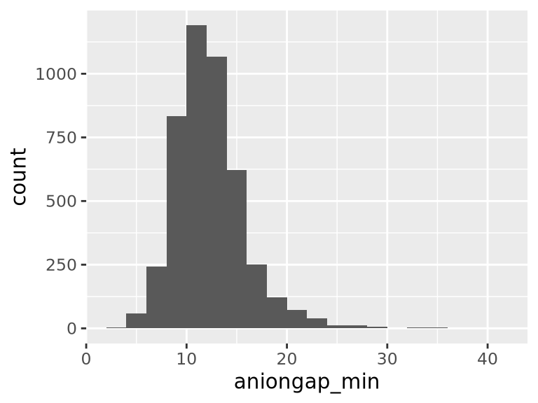

- Note that the following possible outlier values were detected: "3", "4", "5", "6", "29", …, "32", "33", "35", "36", "42" (2 values omitted).

## aniongap_max

| Feature | Result |
| --- | --- |
| Variable type | numeric |
| Number of missing obs. | 14 (0.31 %) |
| Number of unique values | 43 |
| Median | 16 |
| 1st and 3rd quartiles | 13; 19 |
| Min. and max. | 6; 56 |

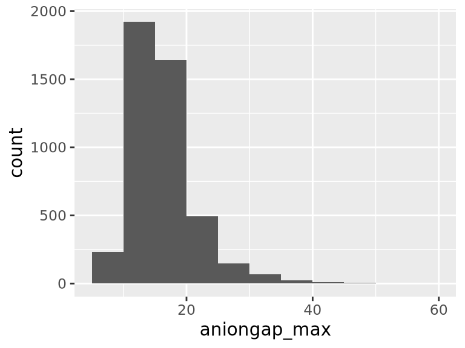

- Note that the following possible outlier values were detected: "6", "7", "32", "33", "34", …, "44", "46", "47", "54", "56" (9 values omitted).

## bicarbonate_min

| Feature | Result |
| --- | --- |
| Variable type | numeric |
| Number of missing obs. | 3 (0.07 %) |
| Number of unique values | 39 |
| Median | 21 |
| 1st and 3rd quartiles | 18; 24 |
| Min. and max. | 5; 45 |

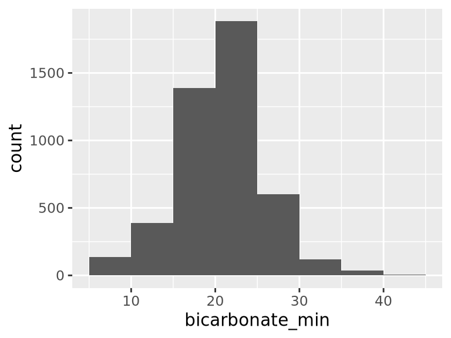

- Note that the following possible outlier values were detected: "5", "6", "7", "8", "34", …, "38", "39", "40", "41", "45" (3 values omitted).

## bicarbonate_max

| Feature | Result |
| --- | --- |
| Variable type | numeric |
| Number of missing obs. | 3 (0.07 %) |
| Number of unique values | 42 |
| Median | 24 |
| 1st and 3rd quartiles | 22; 27 |
| Min. and max. | 8; 49 |

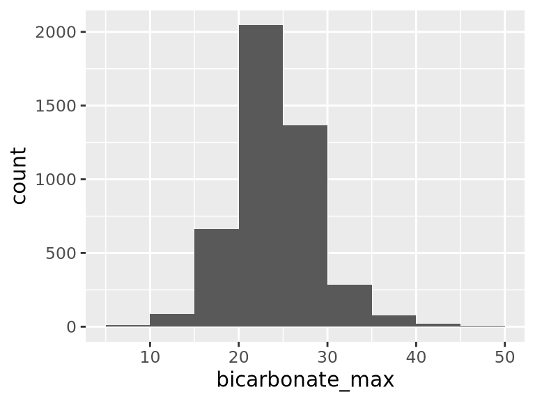

- Note that the following possible outlier values were detected: "8", "9", "10", "11", "12", …, "44", "45", "46", "47", "49" (11 values omitted).

## creatinine_min

| Feature | Result |
| --- | --- |
| Variable type | numeric |
| Number of missing obs. | 2 (0.04 %) |
| Number of unique values | 97 |
| Median | 1 |
| 1st and 3rd quartiles | 0.7; 1.4 |
| Min. and max. | 0.1; 22.1 |

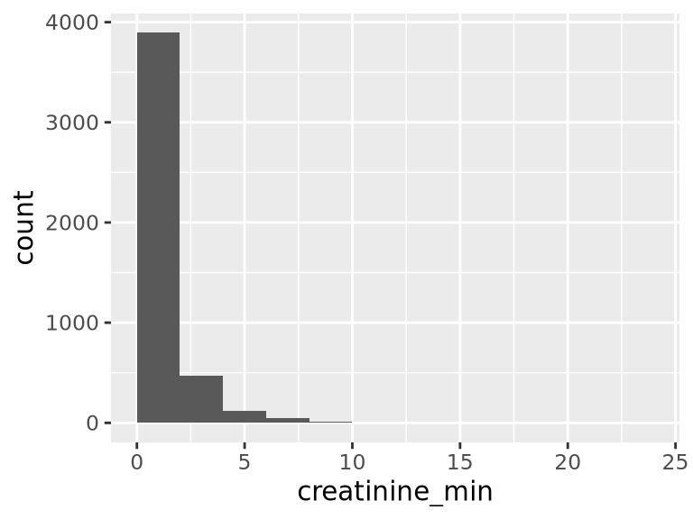

- Note that the following possible outlier values were detected: "0.1", "0.2", "0.3", "0.4", "4.3", …, "11.3", "12", "14.9", "17.3", "22.1" (49 values omitted).

## creatinine_max

| Feature | Result |
| --- | --- |
| Variable type | numeric |
| Number of missing obs. | 2 (0.04 %) |
| Number of unique values | 122 |
| Median | 1.2 |
| 1st and 3rd quartiles | 0.9; 1.9 |
| Min. and max. | 0.1; 27.8 |

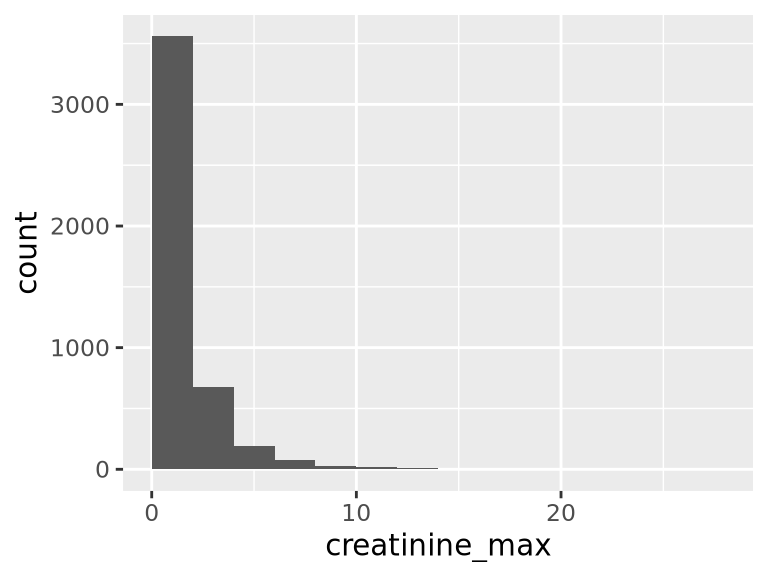

- Note that the following possible outlier values were detected: "0.1", "0.2", "0.3", "0.4", "0.5", …, "16", "17", "20.6", "27.5", "27.8" (45 values omitted).

## chloride_min

| Feature | Result |
| --- | --- |
| Variable type | numeric |
| Number of missing obs. | 1 (0.02 %) |
| Number of unique values | 66 |
| Median | 102 |
| 1st and 3rd quartiles | 98; 106 |
| Min. and max. | 58; 139 |

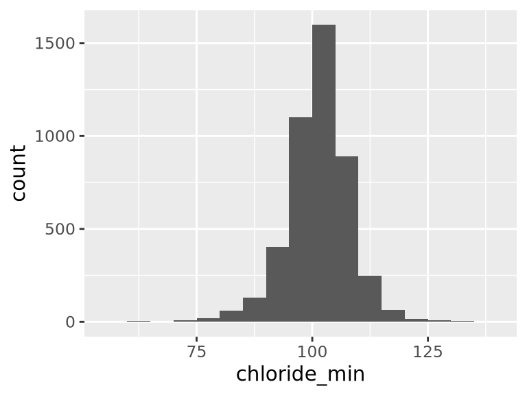

- Note that the following possible outlier values were detected: "58", "61", "62", "64", "65", …, "127", "128", "133", "134", "139" (23 values omitted).

## chloride_max

| Feature | Result |
| --- | --- |
| Variable type | numeric |
| Number of missing obs. | 1 (0.02 %) |
| Number of unique values | 64 |
| Median | 108 |
| 1st and 3rd quartiles | 104; 112 |
| Min. and max. | 67; 155 |

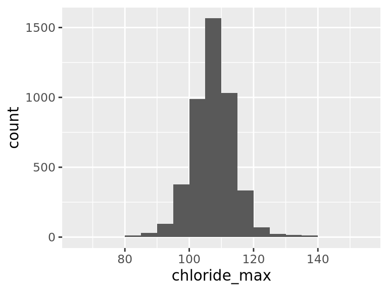

- Note that the following possible outlier values were detected: "67", "80", "81", "82", "84", …, "139", "140", "141", "144", "155" (21 values omitted).

## glucose_min

| Feature | Result |
| --- | --- |
| Variable type | numeric |
| Number of missing obs. | 0 (0 %) |
| Number of unique values | 257 |
| Median | 106 |
| 1st and 3rd quartiles | 90; 127 |
| Min. and max. | 15; 425 |

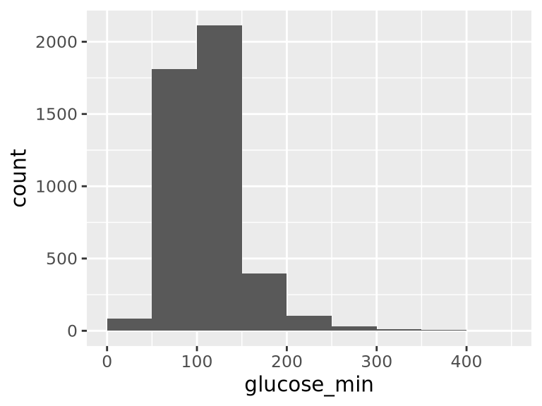

- Note that the following possible outlier values were detected: "15", "19", "20", "21", "22", …, "353", "355", "359", "424", "425" (91 values omitted).

## glucose_max

| Feature | Result |
| --- | --- |
| Variable type | numeric |
| Number of missing obs. | 0 (0 %) |
| Number of unique values | 473 |
| Median | 161 |
| 1st and 3rd quartiles | 128; 211 |
| Min. and max. | 38; 2275 |

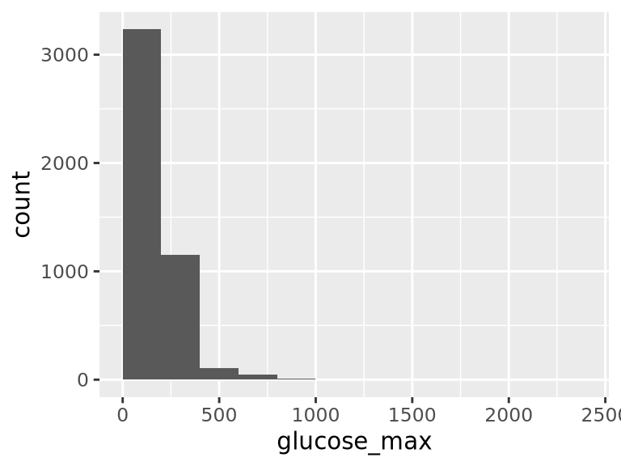

- Note that the following possible outlier values were detected: "38", "40", "56", "57", "58", …, "1155", "1208", "1317", "1689", "2275" (107 values omitted).

## hematocrit_min

| Feature | Result |
| --- | --- |
| Variable type | numeric |
| Number of missing obs. | 3 (0.07 %) |
| Number of unique values | 340 |
| Median | 29.5 |
| 1st and 3rd quartiles | 25.3; 34 |
| Min. and max. | 9; 55.9 |

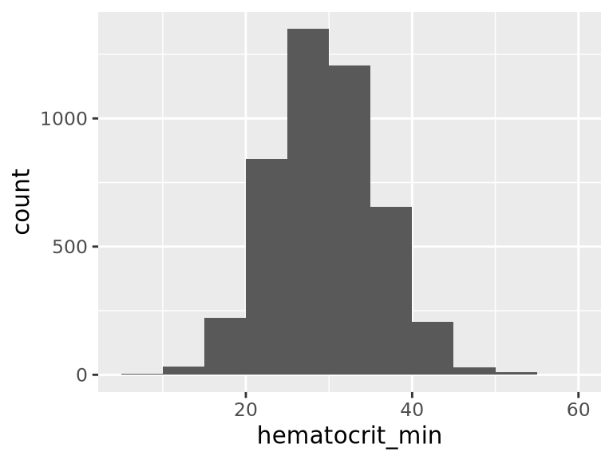

- Note that the following possible outlier values were detected: "9", "9.1", "9.9", "10.6", "11", …, "52.8", "53.3", "54", "54.5", "55.9" (18 values omitted).

## hematocrit_max

| Feature | Result |
| --- | --- |
| Variable type | numeric |
| Number of missing obs. | 3 (0.07 %) |
| Number of unique values | 330 |
| Median | 35.6 |
| 1st and 3rd quartiles | 31.6; 40 |
| Min. and max. | 16.4; 61 |

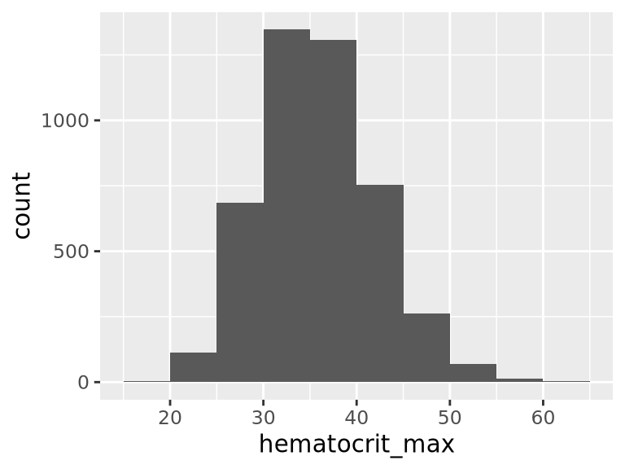

- Note that the following possible outlier values were detected: "16.4", "18.1", "19.1", "20.3", "20.6", …, "59.1", "60.4", "60.5", "60.9", "61" (14 values omitted).

## hemoglobin_min

| Feature | Result |
| --- | --- |
| Variable type | numeric |
| Number of missing obs. | 3 (0.07 %) |
| Number of unique values | 138 |
| Median | 9.9 |
| 1st and 3rd quartiles | 8.5; 11.4 |
| Min. and max. | 2.7; 18 |

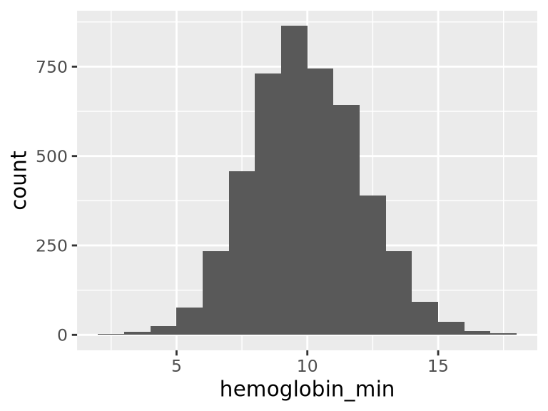

- Note that the following possible outlier values were detected: "2.7", "2.9", "3", "3.2", "3.5", …, "16.6", "17.2", "17.4", "17.5", "18" (14 values omitted).

## hemoglobin_max

| Feature | Result |
| --- | --- |
| Variable type | numeric |
| Number of missing obs. | 3 (0.07 %) |
| Number of unique values | 129 |
| Median | 11.85 |
| 1st and 3rd quartiles | 10.4; 13.4 |
| Min. and max. | 4.8; 19.6 |

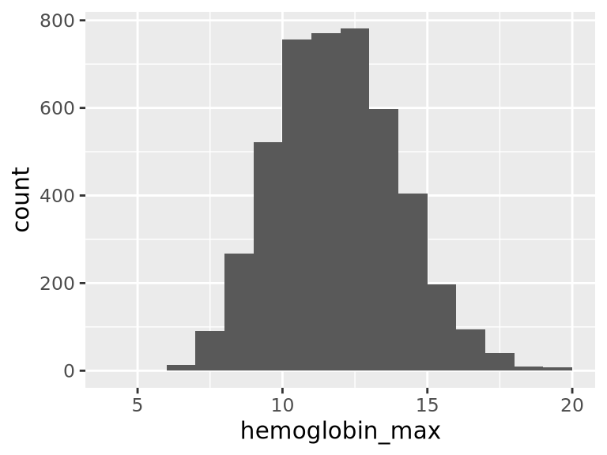

- Note that the following possible outlier values were detected: "4.8", "6", "6.3", "6.4", "18.5", …, "19.1", "19.3", "19.4", "19.5", "19.6" (1 values omitted).

## lactate_min

| Feature | Result |
| --- | --- |
| Variable type | numeric |
| Number of missing obs. | 0 (0 %) |
| Number of unique values | 97 |
| Median | 1.4 |
| 1st and 3rd quartiles | 1; 2 |
| Min. and max. | 0.3; 20.3 |

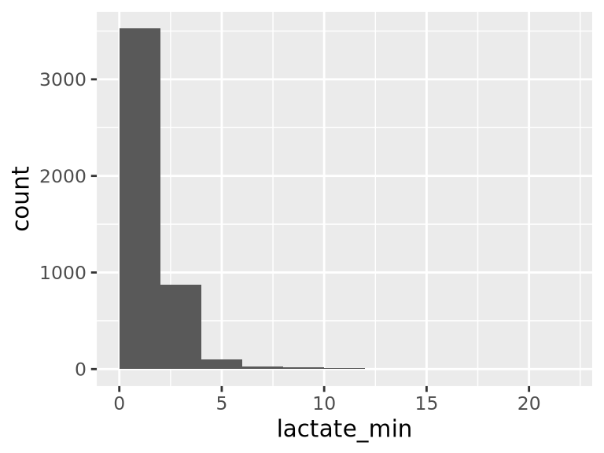

- Note that the following possible outlier values were detected: "0.3", "0.4", "5.4", "5.5", "5.6", …, "12.1", "12.6", "13.2", "15.6", "20.3" (37 values omitted).

## lactate_max

| Feature | Result |
| --- | --- |
| Variable type | numeric |
| Number of missing obs. | 0 (0 %) |
| Number of unique values | 165 |
| Median | 2.2 |
| 1st and 3rd quartiles | 1.5; 3.5 |
| Min. and max. | 0.3; 32 |

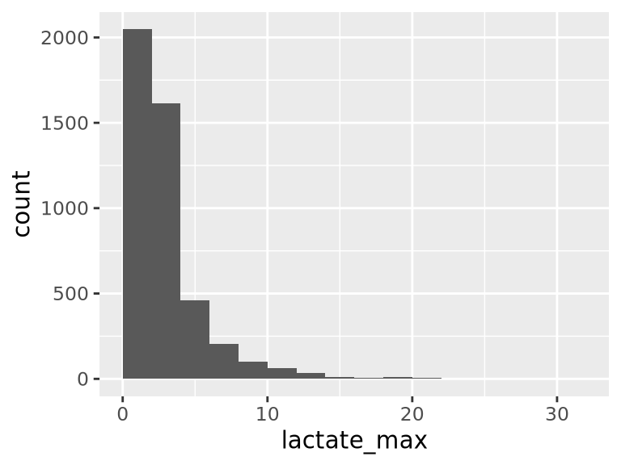

- Note that the following possible outlier values were detected: "0.3", "0.4", "0.5", "0.6", "0.7", …, "21.2", "21.4", "22.4", "23.5", "32" (40 values omitted).

## lactate_mean

| Feature | Result |
| --- | --- |
| Variable type | numeric |
| Number of missing obs. | 0 (0 %) |
| Number of unique values | 209 |
| Median | 1.9 |
| 1st and 3rd quartiles | 1.35; 2.75 |
| Min. and max. | 0.3; 20.85 |

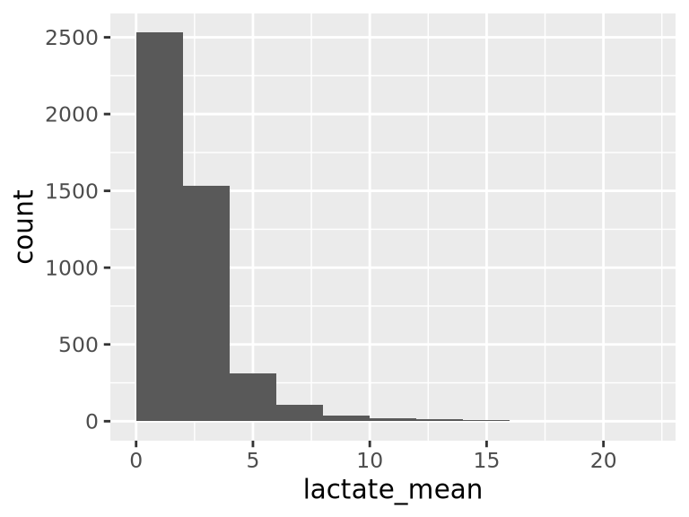

- Note that the following possible outlier values were detected: "0.3", "0.4", "0.45", "0.5", "0.55", …, "15.35", "15.55", "16.8", "19.55", "20.85" (58 values omitted).

## platelet_min

| Feature | Result |
| --- | --- |
| Variable type | numeric |
| Number of missing obs. | 6 (0.13 %) |
| Number of unique values | 527 |
| Median | 178 |
| 1st and 3rd quartiles | 122; 246 |
| Min. and max. | 5; 1297 |

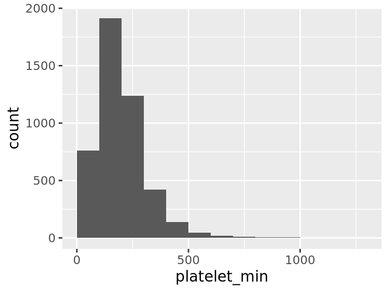

- Note that the following possible outlier values were detected: "5", "6", "7", "8", "9", …, "951", "961", "996", "1039", "1297" (57 values omitted).

## platelet_max

| Feature | Result |
| --- | --- |
| Variable type | numeric |
| Number of missing obs. | 6 (0.13 %) |
| Number of unique values | 608 |
| Median | 224 |
| 1st and 3rd quartiles | 159; 303 |
| Min. and max. | 16; 1775 |

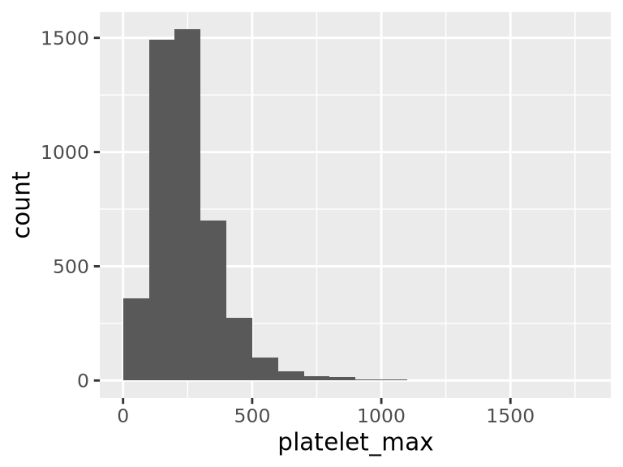

- Note that the following possible outlier values were detected: "16", "18", "19", "20", "21", …, "1081", "1163", "1308", "1418", "1775" (73 values omitted).

## potassium_min

| Feature | Result |
| --- | --- |
| Variable type | numeric |
| Number of missing obs. | 0 (0 %) |
| Number of unique values | 51 |
| Median | 3.7 |
| 1st and 3rd quartiles | 3.4; 4.1 |
| Min. and max. | 0.9; 6.8 |

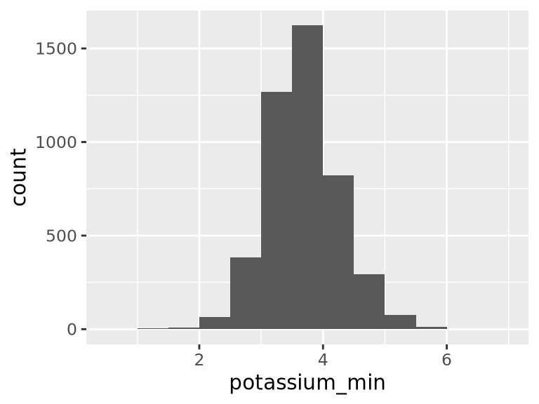

- Note that the following possible outlier values were detected: "0.9", "1.2", "1.4", "1.5", "1.7", …, "5.9", "6", "6.2", "6.4", "6.8" (13 values omitted).

## potassium_max

| Feature | Result |
| --- | --- |
| Variable type | numeric |
| Number of missing obs. | 0 (0 %) |
| Number of unique values | 73 |
| Median | 4.5 |
| 1st and 3rd quartiles | 4.1; 5.1 |
| Min. and max. | 2.3; 13.5 |

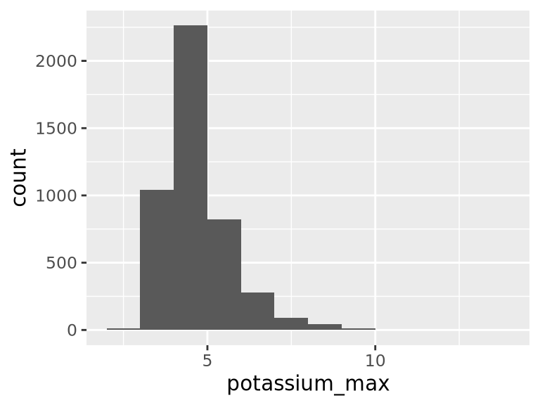

- Note that the following possible outlier values were detected: "2.3", "2.8", "2.9", "3", "3.1", …, "9.7", "9.8", "9.9", "10.2", "13.5" (17 values omitted).

## inr_min

| Feature | Result |
| --- | --- |
| Variable type | numeric |
| Number of missing obs. | 270 (5.92 %) |
| Number of unique values | 68 |
| Median | 1.2 |
| 1st and 3rd quartiles | 1.1; 1.4 |
| Min. and max. | 0.6; 14.6 |

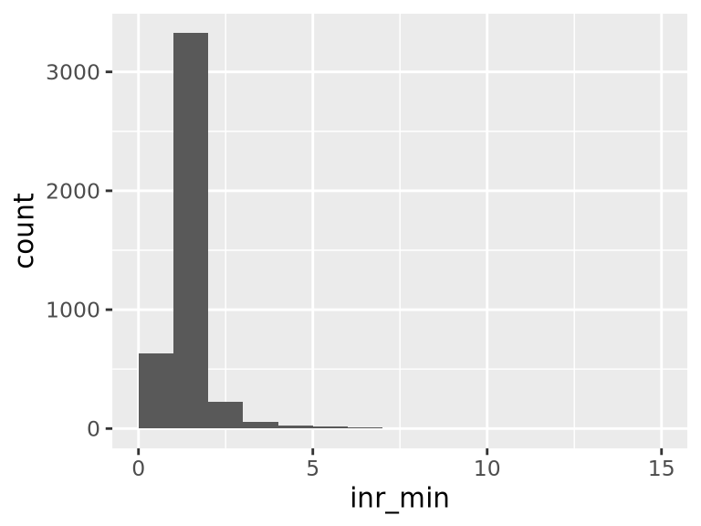

- Note that the following possible outlier values were detected: "0.6", "0.7", "0.8", "0.9", "2.7", …, "7.1", "7.7", "12", "13", "14.6" (38 values omitted).

## inr_max

| Feature | Result |
| --- | --- |
| Variable type | numeric |
| Number of missing obs. | 270 (5.92 %) |
| Number of unique values | 98 |
| Median | 1.3 |
| 1st and 3rd quartiles | 1.2; 1.7 |
| Min. and max. | 0.6; 24 |

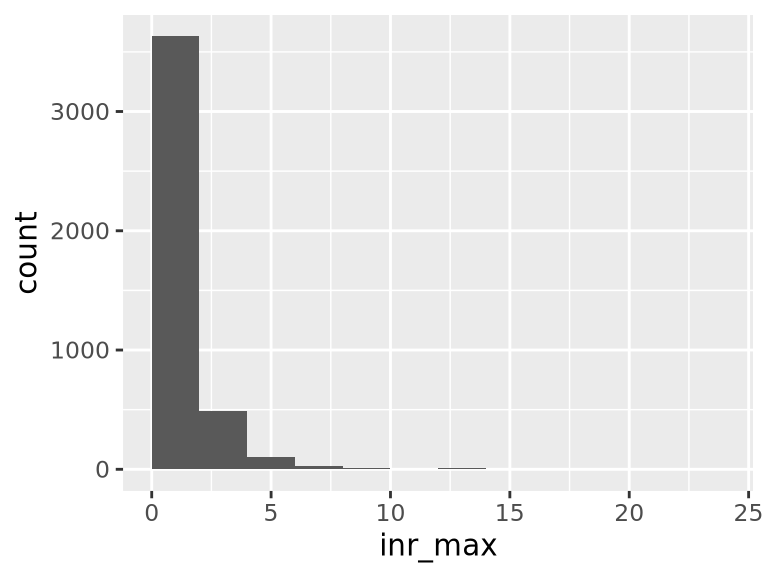

- Note that the following possible outlier values were detected: "0.6", "0.8", "0.9", "1", "5.1", …, "18.8", "21", "21.1", "21.5", "24" (47 values omitted).

## sodium_min

| Feature | Result |
| --- | --- |
| Variable type | numeric |
| Number of missing obs. | 0 (0 %) |
| Number of unique values | 61 |
| Median | 136 |
| 1st and 3rd quartiles | 133; 139 |
| Min. and max. | 74; 166 |

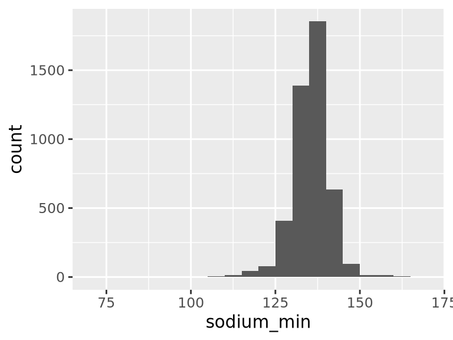

- Note that the following possible outlier values were detected: "74", "95", "103", "104", "106", …, "160", "162", "163", "165", "166" (26 values omitted).

## sodium_max

| Feature | Result |
| --- | --- |
| Variable type | numeric |
| Number of missing obs. | 0 (0 %) |
| Number of unique values | 63 |
| Median | 140 |
| 1st and 3rd quartiles | 138; 143 |
| Min. and max. | 108; 182 |

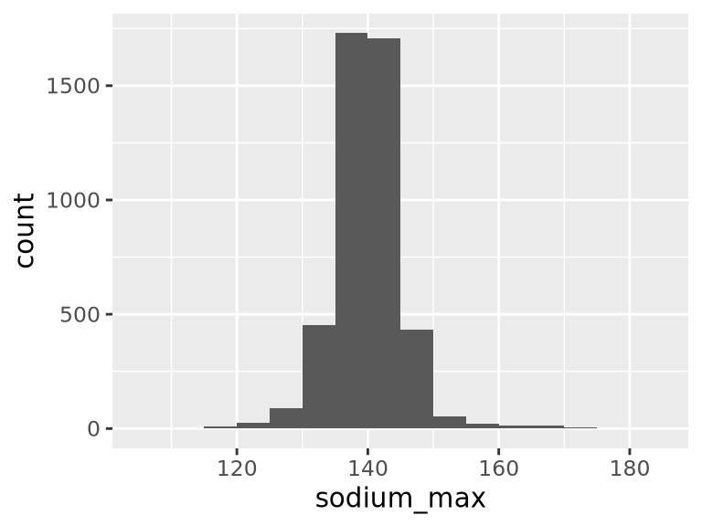

- Note that the following possible outlier values were detected: "108", "113", "114", "116", "117", …, "173", "174", "175", "180", "182" (33 values omitted).

## bun_min

| Feature | Result |
| --- | --- |
| Variable type | numeric |
| Number of missing obs. | 2 (0.04 %) |
| Number of unique values | 139 |
| Median | 19 |
| 1st and 3rd quartiles | 13; 32 |
| Min. and max. | 1; 182 |

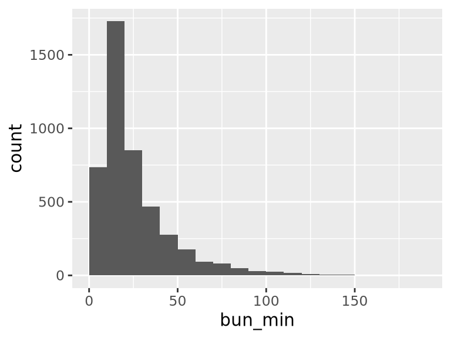

- Note that the following possible outlier values were detected: "1", "2", "3", "4", "5", …, "152", "155", "160", "181", "182" (16 values omitted).